# Chapter 4 Integration

```r
# libraries for this chapter
library(tidyverse)
library(Seurat)
library(data.table)
```

# Load RData

Load the RData which contains all files from previous chapter.

```r
load("data/intermediate_data/chapter3.RData")
```

# 1. To integrate or not to integrate?

The goal of integration is to find corresponding cell states across conditions (or experiments). We want to identify cell types which are present in all samples/conditions/modalities within our dataset. We expect to observe a representation of cells from samples/conditions/modalities in every cluster.

We first look at how cells cluster **without integration** to determine whether integration is necessary. Integration is considered if cells cluster separately on samples/conditions/modalities, etc.

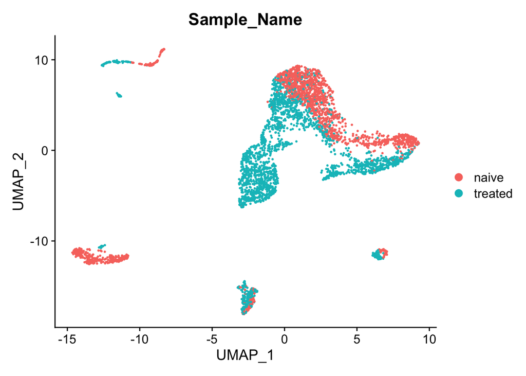

```r
# Run the standard workflow for visualization
filtered.rna <- RunUMAP(filtered.rna, dims = 1:15)

DimPlot(filtered.rna, group.by = "Sample_Name")
```

**Question**

Judging by the UMAP, do the two samples need to be integrated?

**Answer**

The same cell types from the two samples are not aligned. One may consider to perform integration.

# 2. Perform integration

First, we select the variable features. The features should be selected in each dataset.

```r
# split the dataset into a list of two seurat objects (treated and naive)
split.filtered.rna <- SplitObject(filtered.rna, split.by = "Sample_Name")

# normalize and identify variable features for each dataset independently
split.filtered.rna <- lapply(X = split.filtered.rna, FUN = function(x) {
    x <- NormalizeData(x)
    x <- FindVariableFeatures(x, selection.method = "vst", nfeatures = 2000)
})

# Select the most variable features to use for integration
integ.features <- SelectIntegrationFeatures(object.list = split.filtered.rna,
                                            nfeatures = 2000)
```

Next, we perform the integration across samples. This step can take a while to run.

```r
anchors <- FindIntegrationAnchors(object.list = split.filtered.rna,
                                  anchor.features = integ.features)
```

Finally, we can integrate across samples. By default, `normalization.method` is set to `LogNormalize`.

```r
integrate.filtered.rna <- IntegrateData(anchorset = anchors)
```

# 3. UMAP visualization

After integration, we look at the integrated data on UMAP. To calculate UMAP, we need to first calculate PCA and select top PCs.

Methods to select top PCs were used a lot more often when the data was normalized with `LogNormalize`.

```r
integrate.filtered.rna <- ScaleData(integrate.filtered.rna, verbose = FALSE)
integrate.filtered.rna <- RunPCA(integrate.filtered.rna, npcs = 50, verbose = FALSE)
```

Elbow plot can help to select top PCs. The PC number, where the elbow is, is used to calculate UMAP.

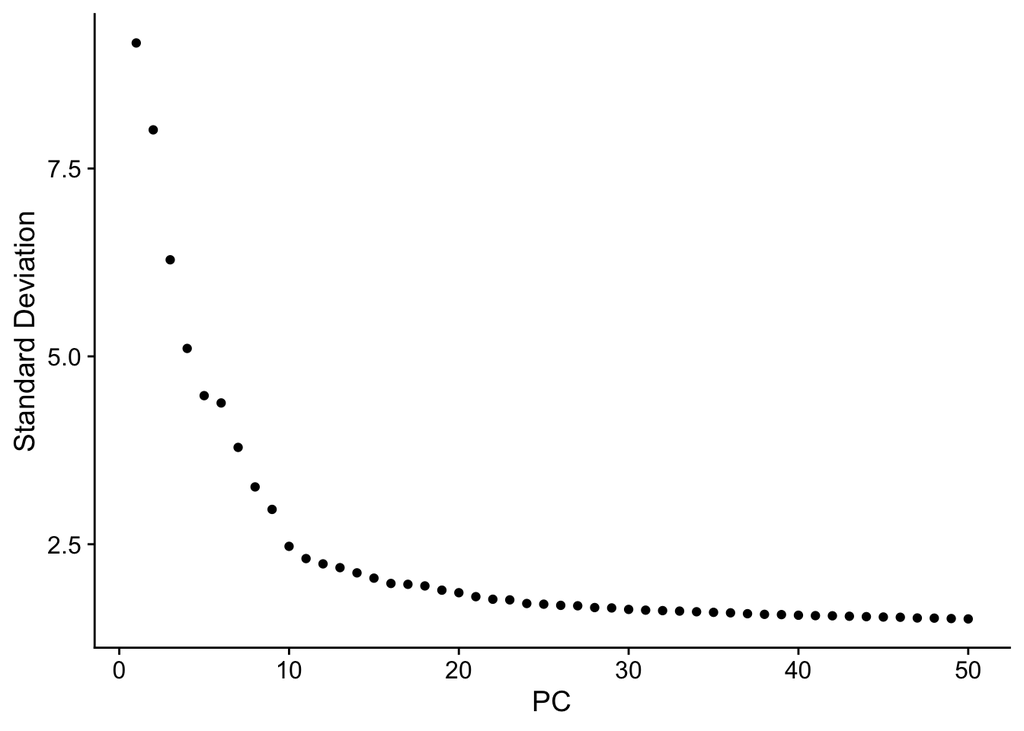

```r
ElbowPlot(integrate.filtered.rna, ndims = 50)
```

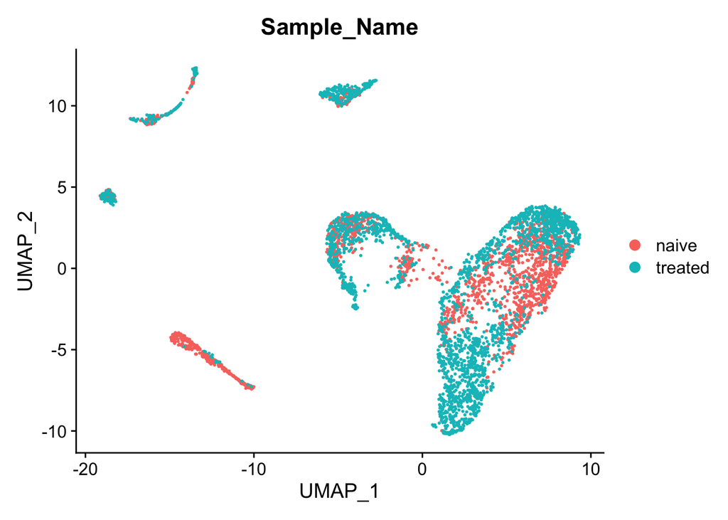

```r
integrate.filtered.rna <- RunUMAP(integrate.filtered.rna,
                                  reduction = "pca",
                                  dims = 1:10)

integrate.filtered.rna <- FindNeighbors(integrate.filtered.rna,
                                        reduction = "pca",
                                        dims = 1:10)


# Plot UMAP
DimPlot(integrate.filtered.rna, group.by = "Sample_Name")
```

**Exercise 1**

Change the number of PCs and see how the UMAP changes.

Tips: You can change the PC numbers by `dims` argument in `RunUMAP`.

**Exercise 2**

`Dimplot` has many arguments to control the plots.

1. Search `Dimplot` in the “Help” tab and read the documentation.
2. Change `group.by` to `split.by`. What is the difference?

When we compare the similarity between the naive and treated clusters in the plots with or without integration, it is clear that this dataset benefits from the integration.

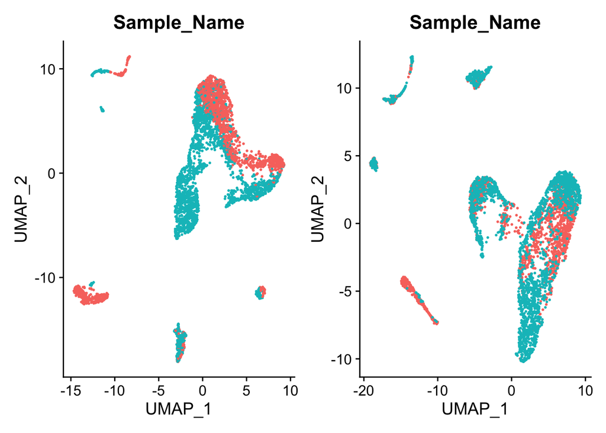

```r
p1 <- DimPlot(filtered.rna, group.by = "Sample_Name") + NoLegend()
p2 <- DimPlot(integrate.filtered.rna, group.by = "Sample_Name")  + NoLegend()

p1|p2
```

# 4. Save

Save the files into RData for documentation.

```r
# save(integrate.filtered.rna, expMat, file = "data/intermediate_data/chapter4.RData")
```